[OHI Science](http://ohi-science.org) | [Citation policy](http://ohi-science.org/citation-policy/)

# OHI: Tourism and Recreation

Compiled on Mon Nov 13 14:20:26 2017 by frazier

[REFERENCE RMD FILE: https://cdn.rawgit.com/OHI-Science/ohiprep/master/globalprep/tr/v2017/tr_dataprep.html]

# 1 Summary

This document describes the steps for obtaining the data used to calculate the tourism and recreation goal for the 2017 global assessment.

The general calculation is: tr = Ep * Sr * Tw and Xtr = tr/90th quantile across regions

- Ep = Proportion of workforce directly employed in tourism
- Sr = (S-1)/5; Sustainability of tourism
- Tw = A penalty applied to regions with travel warnings from the US State Department

The following data are used: * Tourism sustainability: TCCI * Proportion of workforce directly employed in tourism: (WEF) * Travel warnings: (U.S. State Department) * Per capita GDP: (World Bank with gaps filled using CIA data), used to gapfill missing values in Tourism sustainability

# 2 Updates from previous assessment

We discovered that the WEF-Economics Global Competitiveness Index data used to estimate sustainability is not compatible across years. New methods are used each year and previous year’s of data are not recalculated using the updated methods. Consequently, we use the most recent data for all scenario years.

We were able to update the following data: * Proportion of jobs in tourism * Travel warnings for 2017 (downloaded: 8/11/2017) * Sustainability

# 3 Some code to set everything up

```r
#setwd('globalprep/tr/v2017') #comment out when knitting

# library(devtools)
# devtools::install_github("ohi-science/ohicore@dev")
library(ohicore)

source('../../../src/R/common.R')
library(readr)
library(stringr)
library(dplyr)
library(tidyr)
library(WDI)
## maximum year of wttc data:
year_max    <- 2015

source('R/tr_fxns.R')
```

# 4 Ep: Proportion of workforce directly employed in tourism

These data are from the World Travel & Tourism Council (http://www.wttc.org/). We use “direct” employment data (eee mazu: globalprep/_raw_data/WTTC/README.md for instructions on obtaining data). The data extend to 2027, but these values are projections. The actual data goes to 2015.

These data are cleaned and formatted using the R/process_WTTC.R script. Missing values are gapfilled using the UN georegion information.

```r
## describe where the raw data are located:
dir_wttc <- file.path(dir_M, 'git-annex/globalprep/_raw_data/WTTC/d2017/raw')

## processing script that formats the WTTC for OHI, saves the following: intermediate/wttc_empd_rgn
source('R/process_WTTC.R', local = TRUE)
```

```
##
## These data were removed for not having any match in the lookup tables:
##
## Other Oceania
##             1
##
## These data were removed for not being of the proper rgn_type (eez,ohi_region) or mismatching region names in the lookup tables:
##                           tmp_type
## tmp_name                   landlocked
##   Armenia                          33
##   Austria                          33
##   Belarus                          33
##   Bolivia                          33
##   Botswana                         33
##   Burkina Faso                     33
##   Burundi                          33
##   Central African Republic         33
##   Chad                             33
##   Czech Republic                   33
##   Ethiopia                         33
##   Hungary                          33
##   Kazakhstan                       33
##   Kyrgyzstan                       33
##   Laos                             33
##   Lesotho                          33
##   Luxembourg                       33
##   Macedonia                        33
##   Malawi                           33
##   Mali                             33
##   Moldova                          33
##   Mongolia                         33
##   Nepal                            33
##   Niger                            33
##   Paraguay                         33
##   Rwanda                           33
##   Serbia                           33
##   Slovakia                         33
##   Swaziland                        33
##   Switzerland                      33
##   Tajikistan                       33
##   Uganda                           33
##   Uzbekistan                       33
##   Zambia                           33
##   Zimbabwe                         33
```

```
##
## DUPLICATES found. Consider using collapse2rgn to collapse duplicates (function in progress).
```

```
## [1] "Guadeloupe and Martinique"
## [2] "Puerto Rico and Virgin Islands of the United States"
## [3] "China"
```

```r
## read in the dataset created by above function:
tr_jobs_pct_tour <- read.csv('intermediate/wttc_empd_rgn.csv', stringsAsFactors = FALSE) %>%
                select(rgn_id, year, jobs_pct)

## format data to have complete years/regions and convert percentage of jobs to proportion of jobs
    rgn_names <- read.csv('https://raw.githubusercontent.com/OHI-Science/ohi-global/draft/eez/spatial/regions_list.csv', stringsAsFactors = FALSE) %>%
    dplyr::select(rgn_id)

    rgn_names <- expand.grid(rgn_id = rgn_names$rgn_id,
                             year = min(tr_jobs_pct_tour$year):max(tr_jobs_pct_tour$year))

tr_data_raw <- rgn_names %>%
    full_join(tr_jobs_pct_tour %>%
                rename(Ep = jobs_pct) %>%
                mutate(Ep = Ep/100) %>%
                mutate(Ep = ifelse(Ep > 1, NA, Ep)),  # Rgn 54, United Arab Emirates appears to have an error bteween 1995-1999, this cuts these
              by = c('rgn_id', 'year'))

## gapfill missing data using UN georegion data:
georegions       <- georegions
georegion_labels <- georegion_labels

tr_data_raw <- tr_data_raw %>%
  left_join(georegions, by = 'rgn_id') %>%
  left_join(georegion_labels, by = 'rgn_id') %>%
  select(-r0) %>%
  filter(rgn_id != c(255, 213)) # ditch disputed regions and Antarctica

tr_data_raw_gf <- tr_data_raw %>%
  group_by(year, r2) %>%
  mutate(Ep_pred_r2 = mean(Ep, na.rm=TRUE)) %>%
  ungroup() %>%
  group_by(year, r1) %>%
  mutate(Ep_pred_r1 = mean(Ep, na.rm=TRUE)) %>%
  ungroup()

tr_data_raw_gf <- tr_data_raw_gf %>%
  mutate(Ep_all = ifelse(is.na(Ep), Ep_pred_r2, Ep)) %>%
  mutate(Ep_all = ifelse(is.na(Ep_all), Ep_pred_r1, Ep_all)) %>%
  mutate(gapfilled = ifelse(is.na(Ep) & !is.na(Ep_all), "gapfilled", NA)) %>%
  mutate(method = ifelse(is.na(Ep) & !is.na(Ep_pred_r2), "UN georegion (r2)", NA)) %>%
  mutate(method = ifelse(is.na(Ep) & is.na(Ep_pred_r2) & !is.na(Ep_pred_r1), "UN georegion (r1)", method))

# save the data

tr_data_gf <- tr_data_raw_gf %>%
  select(rgn_id, year, gapfilled, method)

write.csv(tr_data_gf, "output/tr_jobs_pct_tourism_gf.csv", row.names=FALSE)

tr_data <- tr_data_raw_gf %>%
  select(rgn_id, year, Ep=Ep_all)

write.csv(tr_data, "output/tr_jobs_pct_tourism.csv", row.names=FALSE)


## A quick check to make sure last year's values aren't too crazy different
## (NOTE: the source data has been updated, so there are some changes, but they shouldn't be super different)

old <- read.csv('../v2016/output/tr_jobs_pct_tourism.csv')%>%
  select(rgn_id, year, ep_old=Ep)
new <- read.csv('output/tr_jobs_pct_tourism.csv') %>%
  left_join(old) %>%
  filter(year==2014) %>%
  arrange(ep_old)
new
```

```
##     rgn_id year         Ep     ep_old
## 1      199 2014 0.00537973 0.00491269
## 2       17 2014 0.00580343 0.00502146
## 3      198 2014 0.00949323 0.00896238
## 4      168 2014 0.01089620 0.01079940
## 5       75 2014 0.01239820 0.01313270
## 6       73 2014 0.01182590 0.01362060
## 7      100 2014 0.01073430 0.01538150
## 8      194 2014 0.01897620 0.01548770
## 9      189 2014 0.01850110 0.01629030
## 10     200 2014 0.01660480 0.01660480
## 11     196 2014 0.01576640 0.01683060
## 12     178 2014 0.01731870 0.01715980
## 13      96 2014 0.01333840 0.01753140
## 14     210 2014 0.01689730 0.01844770
```

[output cut: 207 more lines]

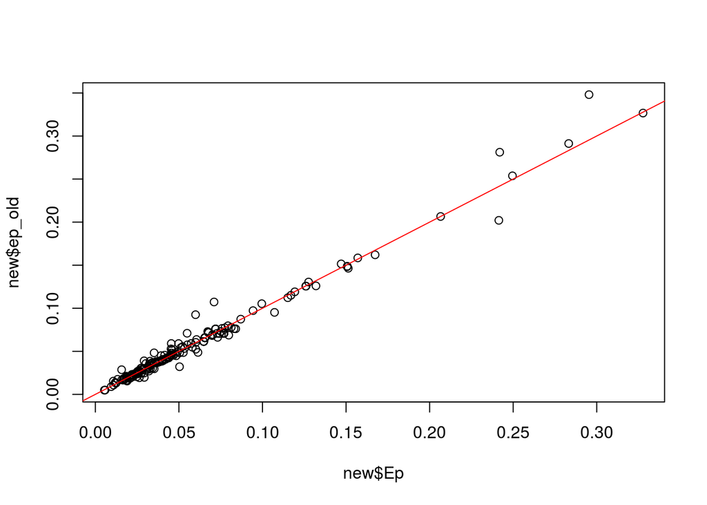

```r
plot(new$Ep, new$ep_old)
abline(0,1, col="red")
```

```r
## NOTE: This looks reasonable to me.
```

# 5 Tw: Travel warnings

Information is from the U.S. State Department (https://travel.state.gov/content/passports/en/alertswarnings.html)

#### 5.0.0.1 A few notes about getting data:

Add the data to tr_travelwarnings_xxx.xls Most of the data can be cut and paste (after it is checked) from the previous year (update the data and year information).

If different regions have different warnings, these are put on two lines and combined in the R script:

assess_year date rgn_name rgn_name_full 2016 4-Feb-15 Cameroon Cameroon risk  
2016 4-Feb-15 Cameroon Cameroon (North and Far North region) avoid_all regional

inform: information travelor should be aware of (election violence, be aware due to crime, etc) risk: risks that trevelors should be aware of (“consider carefully risks of travel”, “warns of risks”) avoid_nonessential travel: “defer non-essential travel” avoid_all: “avoid all travel” gtfo: get out!!!

regional: added if the warning only applies to specific regions

The following code is used to clean these data and transform the warnings into a multiplier that is used to calculate tourism and recreation scores:

```r
scores = data.frame(category = c("inform", "risk", "avoid_nonessential", "avoid_all", "gtfo"),
                    score = c(0, 0.25, 0.75, 1, 1))

warn <- read.csv('raw/tr_travelwarnings_2017.csv') %>%
  select(year = assess_year, rgn_name, inform, risk, avoid_nonessential, avoid_all, gtfo, regional) %>%
  gather("category", "n", 3:7)  %>%
  filter(!is.na(n)) %>%
  select(-n) %>%
  left_join(scores, by="category") %>%
  group_by(year, rgn_name) %>%
  mutate(regions = n())
```

```
## Warning: Column `category` joining character vector and factor, coercing
## into character vector
```

```r
warn2 <- warn %>%
  mutate(score = ifelse(regions %in% 1 & regional %in% 1, score*0.5, score)) %>%
  summarize(score = mean(score)) %>%
  mutate(multiplier = 1-score) %>%
  select(year, rgn_name, multiplier) %>%
  data.frame()

data.frame(filter(warn2, year==2015)) # checked to make sure I got conversions correct, looks good!
```

```
##    year                         rgn_name multiplier
## 1  2015                          Algeria      0.500
## 2  2015                         Cameroon      0.375
## 3  2015                         Colombia      1.000
## 4  2015 Democratic Republic of the Congo      0.750
## 5  2015                         Djibouti      0.750
## 6  2015                      El Salvador      0.750
## 7  2015                          Eritrea      0.750
## 8  2015                            Haiti      1.000
## 9  2015                         Honduras      0.750
## 10 2015                             Iran      0.750
## 11 2015                             Iraq      0.250
## 12 2015                           Israel      0.750
## 13 2015                            Kenya      0.750
## 14 2015                          Lebanon      0.000
```

[output cut: 17 more lines]

```r
warn_rgn <- name_2_rgn(df_in = warn2,
                       fld_name='rgn_name',
                       flds_unique=c('rgn_name','year'))
```

```
##
## These data were removed for not being of the proper rgn_type (eez,ohi_region) or mismatching region names in the lookup tables:
##         tmp_type
## tmp_name landlocked
##    Nepal          1
```

```r
warn_rgn <- warn_rgn %>%
  select(rgn_id, year, multiplier)

write.csv(warn_rgn, 'output/tr_travelwarnings.csv', row.names=FALSE)
```

# 6 Ts: Tourism sustainability

These data are from the World Economic Forum’s “Travel and Tourism Competitiveness Report” (http://reports.weforum.org/travel-and-tourism-competitiveness-report-2015/downloads/) See mazu: _raw_data/WEF-Economics/ for more details and the raw data.

These data are not compatible across years, so only the most recent year of data is across scenarios.

These data are gapfilled using gdppcppp and UN georegion information (see next section for obtaining and preparing these data).

```r
# read in files
ttci_raw <- read.csv(file.path(dir_M, "git-annex/globalprep/_raw_data/WEF-Economics/d2017/wef_ttci.csv"))


ttci <- ttci_raw %>%
    mutate(country = as.character(country)) %>%
    mutate(country = ifelse(country == "Congo, Democratic Rep.", "Democratic Republic of the Congo", country)) %>%
    mutate(country = ifelse(country == "Côte d'Ivoire", "Ivory Coast", country))


ttci_rgn <- name_2_rgn(df_in = ttci,
                       fld_name='country')

weight_data <- data.frame(country = c("China", "Hong Kong SAR"),
                          population = c(1379000000, 7347000))

ttci_rgn <- ttci_rgn %>%
  arrange(country) %>%
  left_join(weight_data, by = "country") %>%
  mutate(population = ifelse(is.na(population), 1, population)) %>%
  group_by(rgn_id, rgn_name) %>%
  summarize(score = weighted.mean(score, population)) %>%
  select(rgn_id, rgn_name, score)

head(ttci_rgn, 10)

### Save TTCI data file
write_csv(ttci_rgn, 'intermediate/wef_ttci.csv')
```

#### 6.0.0.1 Preparing the gdppcppp data:

These data are used to gapfill missing values in tourism sustainability. Most of the data are from the World Bank, but CIA data fill some gaps (CIA data is available for only the most recent year).

The Artisanal Opportunities goal uses gdppcppp data, so we will get the data that was processed for that goal. (NOTE: Update the Artisanal Opportunities goal prior to preparing these data)

```r
wb <- read.csv("../../ao/v2017/intermediate/gdppcppp_ohi.csv") %>%
  dplyr::select(rgn_id, year, value)
```

CIA data are used to fill in missing gaps in the gdppcppp data (https://www.cia.gov/library/publications/the-world-factbook/rankorder/2004rank.html)

Downloaded: 9/11/2017

The following code is used to prepare these data for OHI:

```r
cia_gdp <- read.csv('raw/cia_gdp_pc_ppp.csv', stringsAsFactors = FALSE)


splits <- data.frame(country = "Saint Helena, Ascension, and Tristan da Cunha", country2 = c("Saint Helena",
                                                                                             "Ascension",
                                                                                             "Tristan da Cunha")) %>%
  mutate(country = as.character(country),
         country2 = as.character(country2))

cia_gdp <- cia_gdp %>%
  left_join(splits, by='country') %>%
  mutate(country2 = ifelse(is.na(country2), country, country2)) %>%
  select(country=country2, pcgdp_cia = gdppcppp)


cia_gdp_rgn <- name_2_rgn(df_in = cia_gdp,
                       fld_name='country')

### Collapse regions (regions we include as a single region)

population_weights <- data.frame(country = c("Virgin Islands", "Puerto Rico",
                                             "China", "Hong Kong", "Macau",
                                             "Guam", "Northern Mariana Islands"),
                                 population = c(106405, 3725789,
                                         1339724852, 7071576, 636200,
                                         162896, 55023))

cia_gdp_rgn <- cia_gdp_rgn %>%
  left_join(population_weights, by="country") %>%
  mutate(population = ifelse(is.na(population), 1, population)) %>%
  group_by(rgn_id) %>%
  summarize(pcgdp_cia = weighted.mean(pcgdp_cia, population)) %>%
  ungroup() %>%
  filter(rgn_id <= 250) %>%
  select(rgn_id, pcgdp_cia)

write.csv(cia_gdp_rgn, "intermediate/wb_rgn_cia_GDPPCPPP.csv", row.names=FALSE)
```

The following code combines the two gdp datasets and gapfills missing regions using UN georegions.

If there is no World Bank gdppcppp data (pcgdp), the CIA data is used (pcgdp_cia). The pcgdp2 variable includes both the World Bank and CIA data (with CIA data only used if there is not World Bank data). The remaining data are estimated using UN geopolitical regions. Ideally, the mean gdppcppp value is calculated at the r2 scale (gdp_pred_r2) using regions within each class with gdppcppp data. If there were not enough regions with data at the r2 scale, the average at the r1 scale was used (gdp_pred_r1). The gdp_all variable combines all estimates using the following heirarchy: World Bank -> CIA -> estimated using mean from r2 UN geopolitical regions -> estimated using mean from r1 UN geopolitical regions.

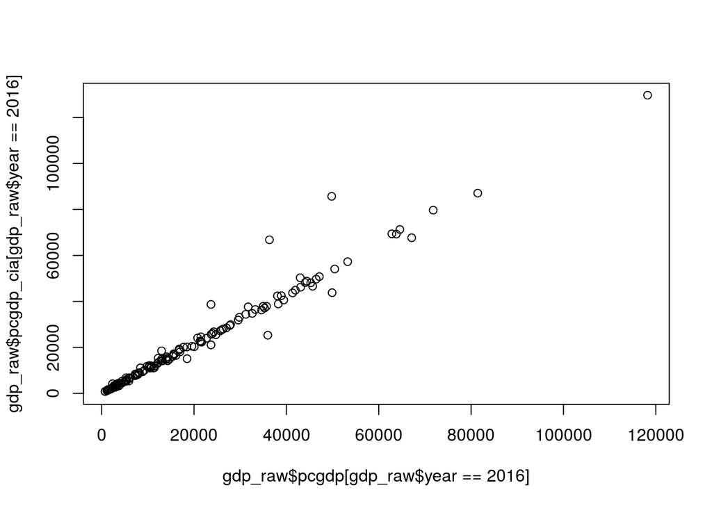

```r
### world bank gdp data
gdppcppp <- wb %>%
  select(rgn_id, year, pcgdp = value)

### cia gdp data
gdppcppp2 <- read.csv('intermediate/wb_rgn_cia_GDPPCPPP.csv')


### Use WB data, but if missing, use pcgdp_cia.
### combine with UN georegion data
expand.grid.df <- function(...) Reduce(function(...) merge(..., by=NULL), list(...))

regions <- georegions %>%
  left_join(georegion_labels, by = 'rgn_id')

gdp_raw <- expand.grid.df(regions, data.frame(year = min(gdppcppp$year):max(gdppcppp$year))) %>%
   left_join(gdppcppp, by = c('rgn_id', 'year')) %>%
  left_join(gdppcppp2, by = c("rgn_id"))

## quick compare to make sure the CIA and World Bank data are compatible
plot(gdp_raw$pcgdp[gdp_raw$year==2016], gdp_raw$pcgdp_cia[gdp_raw$year==2016])
```

```r
# a bit of scatter for a few regions, but overall looks good

gdp_raw <- gdp_raw %>%
  mutate(pcgdp2 = ifelse(is.na(pcgdp), pcgdp_cia, pcgdp))

gdp_raw <- gdp_raw %>%
  group_by(r2, year) %>%
  mutate(gdp_pred_r2 = mean(pcgdp2, na.rm=TRUE)) %>%
  ungroup() %>%
  group_by(r1, year) %>%
  mutate(gdp_pred_r1 = mean(pcgdp2, na.rm=TRUE)) %>%
  ungroup()

gdp_raw_gf <- gdp_raw %>%
  mutate(gdp_all = ifelse(is.na(pcgdp2), gdp_pred_r2, pcgdp2)) %>%
  mutate(gdp_all = ifelse(is.na(gdp_all), gdp_pred_r1, gdp_all)) %>%
  mutate(gapfilled = ifelse(is.na(pcgdp2) & !is.na(gdp_all), "gapfilled", NA)) %>%
  mutate(method = ifelse(is.na(pcgdp2) & !is.na(gdp_pred_r2), "UN georegion (r2)", NA)) %>%
  mutate(method = ifelse(is.na(pcgdp2) & is.na(gdp_pred_r2) & !is.na(gdp_pred_r1), "UN georegion (r1)", method))

write_csv(gdp_raw_gf, "intermediate/gdp_raw_gf.csv")

gdp_data_gf <- gdp_raw_gf %>%
  select(rgn_id, year, gapfilled, method)

write_csv(gdp_data_gf, "intermediate/gdp_gf.csv")

gdp_data <- gdp_raw_gf %>%
  select(rgn_id, year, pcgdp = gdp_all)

write_csv(gdp_data, "intermediate/gdp.csv")
```

The final step is gapfilling the Sustainability data using a linear model with gdppcppp and UN geopolitical regions as predictor variables.

```r
sust  <- read.csv('intermediate/wef_ttci.csv', stringsAsFactors = FALSE)

### don't need to gapfill data without tourism data:
## Most recent tourism data is 2015.

ep_gf <- read.csv("output/tr_jobs_pct_tourism.csv") %>%
  filter(year == 2015) %>%
  select(rgn_id, Ep) %>%
  filter(!is.na(Ep))

gdp_raw_gf <- read.csv("intermediate/gdp_raw_gf.csv", stringsAsFactors = FALSE) %>%
  filter(year == 2016) %>%
  select(rgn_id, r0_label, r1_label, r2_label, rgn_label, pcgdp, pcgdp_cia, pcgdp2, gdp_all)

tr_sust <- gdp_raw_gf %>%
           left_join(sust, by = c("rgn_id")) %>%
          left_join(ep_gf, by = c("rgn_id")) %>%
          rename(S_score = score) %>%
          filter(rgn_id != 213)

### Add gapfill flag variable

tr_sust_gf <- tr_sust %>%
  mutate(gapfilled = ifelse(is.na(S_score) & !is.na(Ep), "gapfilled", NA)) %>%
  mutate(method = ifelse(is.na(S_score) & !is.na(Ep) & is.na(pcgdp2), "lm georegion + gdppcppp, with est. gdppcppp", NA)) %>%
  mutate(method = ifelse(is.na(S_score) & !is.na(Ep) & !is.na(pcgdp2), "lm georegion + gdppcppp", method)) %>%
  select(rgn_id, gapfilled, method)
write.csv(tr_sust_gf, "output/tr_sustainability_gf.csv", row.names=FALSE)


##############################################################################=
### Gapfilling ----
##############################################################################=


### Gapfill S using r1 and/or r2 regional data and PPP-adjusted per-capita GDP
### Looked at models with a year variable, but wasn't significant and decided to exclude

mod3 <- lm(S_score ~ as.factor(r2_label) + gdp_all, data=tr_sust, na.action = na.exclude)
summary(mod3)
anova(mod3)

mod4 <- lm(S_score ~ as.factor(r1_label) + gdp_all, data=tr_sust, na.action = na.exclude)
summary(mod4)
anova(mod4)

plot(predict(mod3), tr_sust$S_score)
abline(0,1)
plot(predict(mod4), tr_sust$S_score)
abline(0,1)


## Estimate missing data and gapfill
# Some of the r1 levels do not have data and consequently causes a fail.
# Need to drop these levels so an NA is returned
new_data <- tr_sust[, c("r2_label", "gdp_all")]
unique(tr_sust$r2_label)
r2_w_data <- unique(tr_sust$r2_label[!is.na(tr_sust$S_score)])
new_data_r2 <- new_data %>%
  mutate(r2_label = ifelse(r2_label %in% r2_w_data, r2_label, NA))

tr_sust$S_score_pred_r2 <- predict(mod3, newdata = new_data_r2)

new_data <- tr_sust[, c("r1_label", "gdp_all")]
unique(tr_sust$r1_label)
r1_w_data <- unique(tr_sust$r1_label[!is.na(tr_sust$S_score)])
new_data_r1 <- new_data %>%
  mutate(r1_label = ifelse(r1_label %in% r1_w_data, r1_label, NA))

tr_sust$S_score_pred_r1 <- predict(mod4, newdata = new_data_r1)

## some are missing the r1 predictions, but none of these have Ep scores, so not relevant
filter(tr_sust, is.na(S_score_pred_r1))

tr_sust <- tr_sust %>%
  mutate(S_score_2 = ifelse(is.na(S_score), S_score_pred_r2, S_score)) %>%
  mutate(S_score_2 = ifelse(is.na(S_score_2), S_score_pred_r1, S_score_2)) %>%
  mutate(year = '2017') %>%
#  filter(!is.na(Ep)) %>%
  select(rgn_id, year, S_score=S_score_2)
summary(tr_sust)
write_csv(tr_sust, "output/tr_sustainability.csv")

## compare with previous year of data
compare <- read.csv("../v2015/data/tr_sustainability.csv") %>%
  select(rgn_id, old_S_score = S_score) %>%
  left_join(tr_sust, by = "rgn_id") %>%
  mutate(dif = old_S_score - S_score)

plot(compare$S_score, compare$old_S_score)
abline(0, 1, col="red")
#looks reasonable
```